# Clasificación Aviar en Ibagué mediante Deep Learning: Enfoque en Precisión y Eficiencia

El proceso de clasificación aviar en Ibagué, mediante técnicas de Deep Learning, reviste una importancia fundamental en la conservación y el estudio de la biodiversidad de la región. Ibagué, ubicada en una zona geográfica rica en diversidad de aves, se enfrenta a desafíos significativos en la identificación y monitoreo de estas especies. La implementación de un sistema multiclase de identificación aviar no solo facilita la tarea de catalogación para investigadores y conservacionistas, sino que también proporciona una herramienta eficaz para la evaluación del estado de las poblaciones aviares y la detección temprana de posibles amenazas, como la pérdida de hábitat o el cambio climático. Con un enfoque en la precisión y eficiencia del proceso de clasificación, este sistema puede contribuir de manera significativa a la gestión sostenible de los recursos naturales y la protección del medio ambiente en la región de Ibagué.

## Librerias

A continuación se relacionana algunas de las bibliotecas y módulos de Python que se utilizan comúnmente en el desarrollo de aplicaciones de aprendizaje automático, procesamiento de imágenes y que se utilizaran en este proyecto:

1. **Keras**: Es una biblioteca de redes neuronales de código abierto escrita en Python que facilita la creación y entrenamiento de modelos de aprendizaje profundo. Proporciona una interfaz simple y consistente para construir y entrenar modelos de redes neuronales.
2. **NumPy**: Es una biblioteca fundamental para computación numérica en Python. Se utiliza para realizar operaciones matemáticas en matrices y matrices multidimensionales, lo que es esencial para el procesamiento de datos en el aprendizaje automático.
3. **OpenCV (cv2)**: OpenCV (Open Source Computer Vision Library) es una biblioteca de código abierto que se utiliza para el procesamiento de imágenes y visión por computadora. Proporciona una amplia gama de funciones y algoritmos para tareas como manipulación de imágenes, detección de características, reconocimiento de objetos, seguimiento de objetos, entre otros.
4. **Matplotlib**: Es una biblioteca de trazado en 2D de Python que produce figuras de calidad de publicación en una variedad de formatos y entornos. Se utiliza para visualizar datos y resultados, incluidas imágenes y gráficos.
5. **TensorFlow**: Es una biblioteca de código abierto desarrollada por Google para el aprendizaje automático y la inteligencia artificial. TensorFlow proporciona un ecosistema completo para construir y entrenar modelos de aprendizaje profundo, incluidas API de alto nivel como Keras.
6. **Scikit-learn**: Es una biblioteca de aprendizaje automático de código abierto que proporciona herramientas simples y eficientes para el análisis predictivo y la minería de datos. Incluye una variedad de algoritmos de aprendizaje supervisado y no supervisado, así como herramientas para preprocesamiento de datos, evaluación de modelos y selección de características.

En resumen, estas bibliotecas son componentes clave en el desarrollo de aplicaciones de aprendizaje automático y procesamiento de imágenes, proporcionando herramientas y funciones para construir, entrenar, evaluar y visualizar modelos de manera eficiente.

```python
from keras.models import Sequential, Model
from keras.layers import Conv2D, MaxPool2D, Dense, Flatten, Dropout, BatchNormalization, Input
from keras.optimizers import Adam
from keras.callbacks import TensorBoard, ModelCheckpoint
from keras.utils import to_categorical
import os
import numpy as np
from keras.preprocessing import image
from keras.applications.imagenet_utils import preprocess_input, decode_predictions
from keras.applications.vgg16 import VGG16
from tensorflow.keras.preprocessing.image import ImageDataGenerator
from tensorflow.keras.models import load_model
from sklearn.utils import shuffle
from sklearn.model_selection import train_test_split
import cv2
import matplotlib.pyplot as plt
%matplotlib inline
```

# Configuración de parámetros

Es crucial establecer los parámetros específicos, como el tamaño de las imágenes de entrada (width_shape y height_shape), el número de clases a predecir (num_classes), así como los hiperparámetros de entrenamiento, como el número de épocas (epochs) y el tamaño del lote (batch_size), antes de iniciar el proceso de entrenamiento de un modelo de aprendizaje profundo para la clasificación de imágenes. Estos parámetros tienen un impacto significativo en la calidad y eficiencia del modelo resultante. Por ejemplo, el tamaño de las imágenes de entrada afecta la capacidad del modelo para capturar detalles importantes de las imágenes, mientras que el número de clases determina la complejidad de la tarea de clasificación. Además, la configuración adecuada de los hiperparámetros de entrenamiento, como el número de épocas y el tamaño del lote, es esencial para garantizar un entrenamiento efectivo y eficiente del modelo, evitando el sobreajuste o el subajuste. Por lo tanto, la correcta especificación de estos parámetros es fundamental para lograr resultados precisos y confiables en el proceso de clasificación de imágenes.

```python
width_shape = 224
height_shape = 224
num_classes = 18
epochs = 50
batch_size = 32
```

# Path de dataset

Estos son los directorios donde se almacenan los datos de entrenamiento y validación respectivamente para el modelo. Es una práctica común dividir el conjunto de datos en un conjunto de entrenamiento y un conjunto de validación para evaluar el rendimiento del modelo durante el entrenamiento.

```python
train_data_dir = 'dataset/train'
validation_data_dir = 'dataset/valid'
```

- `train_data_dir`: Este directorio contiene las imágenes de entrenamiento. Por lo general, se espera que contenga subdirectorios separados para cada clase (cada tipo de ave) de imagen, donde las imágenes de cada clase se agrupan juntas.
- `validation_data_dir`: Este directorio contiene las imágenes de validación, que se utilizan para evaluar el rendimiento del modelo en un conjunto de datos independiente durante el entrenamiento. Al igual que con el directorio de entrenamiento, se espera que este directorio contenga subdirectorios separados para cada clase de imagen.

La estructura de directorios esperada por los generadores de datos de Keras o TensorFlow para tareas de clasificación de imágenes suele ser la siguiente:

```
dataset/
├── train/
│   ├── class1/
│   │   ├── image1.jpg
│   │   ├── image2.jpg
│   │   └── ...
│   ├── class2/
│   │   ├── image1.jpg
│   │   ├── image2.jpg
│   │   └── ...
│   └── ...
└── valid/
    ├── class1/
    │   ├── image1.jpg
    │   ├── image2.jpg
    │   └── ...
    ├── class2/
    │   ├── image1.jpg
    │   ├── image2.jpg
    │   └── ...
    └── ...
```

En esta estructura:

- El directorio `train` contiene subdirectorios separados para cada clase de imagen.
- Cada subdirectorio de clase (`class1`, `class2`, etc.) contiene las imágenes correspondientes a esa clase.
- El directorio `valid` tiene una estructura similar al directorio de entrenamiento y se utiliza para almacenar las imágenes de validación.

Es importante seguir esta estructura de directorios para que los generadores de datos de Keras o TensorFlow puedan encontrar y cargar correctamente las imágenes durante el entrenamiento y la validación del modelo. Si los datos no están organizados de esta manera, los generadores de datos pueden tener dificultades para encontrar las imágenes y el proceso de entrenamiento puede fallar o producir resultados incorrectos.

# Generador de imágenes para las imagenes de `train` y `valid`

Los generadores de imágenes son fundamentales para cargar y procesar los datos de entrenamiento y validación de manera eficiente durante el entrenamiento del modelo de clasificación de imágenes. Además, aplican aumentos de datos en tiempo real durante el entrenamiento, lo que ayuda a mejorar la capacidad del modelo para generalizar a nuevos datos.

```python
# Definir el generador de imágenes para el conjunto de entrenamiento con aumentos de datos
train_datagen = ImageDataGenerator(
    rotation_range=20,               # Rango de grados para rotación aleatoria
    zoom_range=0.2,                  # Rango de zoom aleatorio
    width_shift_range=0.1,           # Rango de desplazamiento horizontal aleatorio
    height_shift_range=0.1,          # Rango de desplazamiento vertical aleatorio
    horizontal_flip=True,            # Volteo horizontal aleatorio
    vertical_flip=False,             # No se aplica volteo vertical
    preprocessing_function=preprocess_input)  # Función de preprocesamiento

# Definir el generador de imágenes para el conjunto de validación con los mismos aumentos de datos
valid_datagen = ImageDataGenerator(
    rotation_range=20,
    zoom_range=0.2,
    width_shift_range=0.1,
    height_shift_range=0.1,
    horizontal_flip=True,
    vertical_flip=False,
    preprocessing_function=preprocess_input)

# Crear un generador de lotes de imágenes para el conjunto de entrenamiento
train_generator = train_datagen.flow_from_directory(
    train_data_dir,                  # Directorio que contiene las imágenes de entrenamiento
    target_size=(width_shape, height_shape),  # Tamaño al que se redimensionarán las imágenes
    batch_size=batch_size,           # Tamaño del lote
    class_mode='categorical')        # Modo de clasificación para imágenes categóricas

# Crear un generador de lotes de imágenes para el conjunto de validación
validation_generator = valid_datagen.flow_from_directory(
    validation_data_dir,             # Directorio que contiene las imágenes de validación
    target_size=(width_shape, height_shape),  # Tamaño al que se redimensionarán las imágenes
    batch_size=batch_size,           # Tamaño del lote
    class_mode='categorical')        # Modo de clasificación para imágenes categóricas
```

```
Found 2805 images belonging to 18 classes.
Found 90 images belonging to 18 classes.
```

# Entrenamiento de modelo VGG16

A continuación, se configura y entrena un modelo de red neuronal convolucional (CNN) utilizando la arquitectura VGG16 preentrenada para la clasificación de imágenes. Primero, se establecen variables para el número de muestras de entrenamiento y validación. Luego, se define la estructura de entrada de la red neuronal y se carga el modelo VGG16 preentrenado con sus pesos ajustados a partir del conjunto de datos ImageNet. Se añade una capa densa adicional para adaptar la salida a la cantidad de clases en el problema de clasificación y se congela el resto de las capas para evitar que se modifiquen durante el entrenamiento. Posteriormente, el modelo se compila con una función de pérdida y un optimizador específicos, y se muestra un resumen de la arquitectura del modelo. Finalmente, se lleva a cabo el entrenamiento del modelo utilizando generadores de datos para el conjunto de entrenamiento y validación, con la configuración de épocas y pasos definida previamente. Durante el entrenamiento, se actualizan únicamente los pesos de la capa densa añadida, mientras que los pesos de las capas preentrenadas permanecen constantes debido a la congelación previa.

# Prueba 1

## **Regularización** L2

Se agrega regularización L2 a la capa densa utilizando el parámetro kernel_regularizer='l2'. La regularización L2 es una técnica comúnmente utilizada para prevenir el sobreajuste en modelos de aprendizaje automático al penalizar los pesos grandes en la función de pérdida. Esto puede ayudar a mejorar la generalización del modelo, especialmente cuando se tienen conjuntos de datos pequeños o complejos.

# Entrenamiento

```python
# Definir el número de muestras de entrenamiento y validación
nb_train_samples = 2805
nb_validation_samples = 90

# Definir la entrada de la red neuronal con el tamaño de las imágenes
image_input = Input(shape=(width_shape, height_shape, 3))

# Cargar el modelo VGG16 preentrenado con pesos ajustados desde ImageNet
model = VGG16(input_tensor=image_input, include_top=True, weights='imagenet')

# Obtener la salida de la penúltima capa densa del modelo VGG16 (fc2)
last_layer = model.get_layer('fc2').output

# Añadir una nueva capa densa al final del modelo para la clasificación multiclase con regularización L2 (Evita sobreajuste)
out = Dense(num_classes, activation='softmax', kernel_regularizer='l2', name='output')(last_layer)

# Crear un nuevo modelo personalizado que toma la entrada de la imagen y produce la salida clasificada
custom_vgg_model = Model(image_input, out)

# Congelar todas las capas del modelo, excepto la capa densa añadida
for layer in custom_vgg_model.layers[:-1]:
    layer.trainable = False

# Compilar el modelo con una función de pérdida, optimizador y métricas especificadas
custom_vgg_model.compile(loss='categorical_crossentropy', optimizer=Adam(learning_rate=0.0001), metrics=['accuracy'])


# Mostrar un resumen del modelo que incluye la arquitectura y el número de parámetros
custom_vgg_model.summary()

# Entrenar el modelo utilizando generadores de datos para el conjunto de entrenamiento y validación
model_history = custom_vgg_model.fit(
    train_generator,
    epochs=epochs,
    validation_data=validation_generator,
    steps_per_epoch=nb_train_samples//batch_size,  # Número de pasos por época de entrenamiento
    validation_steps=nb_validation_samples//batch_size)  # Número de pasos por época de validación
```

```
Model: "functional_1"
```

```
┏━━━━━━━━━━━━━━━━━━━━━━━━━━━━━━━━━┳━━━━━━━━━━━━━━━━━━━━━━━━┳━━━━━━━━━━━━━━━┓
┃ Layer (type)                    ┃ Output Shape           ┃       Param # ┃
┡━━━━━━━━━━━━━━━━━━━━━━━━━━━━━━━━━╇━━━━━━━━━━━━━━━━━━━━━━━━╇━━━━━━━━━━━━━━━┩
│ input_layer (InputLayer)        │ (None, 224, 224, 3)    │             0 │
├─────────────────────────────────┼────────────────────────┼───────────────┤
│ block1_conv1 (Conv2D)           │ (None, 224, 224, 64)   │         1,792 │
├─────────────────────────────────┼────────────────────────┼───────────────┤
│ block1_conv2 (Conv2D)           │ (None, 224, 224, 64)   │        36,928 │
├─────────────────────────────────┼────────────────────────┼───────────────┤
│ block1_pool (MaxPooling2D)      │ (None, 112, 112, 64)   │             0 │
├─────────────────────────────────┼────────────────────────┼───────────────┤
│ block2_conv1 (Conv2D)           │ (None, 112, 112, 128)  │        73,856 │
├─────────────────────────────────┼────────────────────────┼───────────────┤
│ block2_conv2 (Conv2D)           │ (None, 112, 112, 128)  │       147,584 │
├─────────────────────────────────┼────────────────────────┼───────────────┤
│ block2_pool (MaxPooling2D)      │ (None, 56, 56, 128)    │             0 │
├─────────────────────────────────┼────────────────────────┼───────────────┤
│ block3_conv1 (Conv2D)           │ (None, 56, 56, 256)    │       295,168 │
├─────────────────────────────────┼────────────────────────┼───────────────┤
│ block3_conv2 (Conv2D)           │ (None, 56, 56, 256)    │       590,080 │
├─────────────────────────────────┼────────────────────────┼───────────────┤
│ block3_conv3 (Conv2D)           │ (None, 56, 56, 256)    │       590,080 │
├─────────────────────────────────┼────────────────────────┼───────────────┤
│ block3_pool (MaxPooling2D)      │ (None, 28, 28, 256)    │             0 │
├─────────────────────────────────┼────────────────────────┼───────────────┤
│ block4_conv1 (Conv2D)           │ (None, 28, 28, 512)    │     1,180,160 │
├─────────────────────────────────┼────────────────────────┼───────────────┤
│ block4_conv2 (Conv2D)           │ (None, 28, 28, 512)    │     2,359,808 │
├─────────────────────────────────┼────────────────────────┼───────────────┤
│ block4_conv3 (Conv2D)           │ (None, 28, 28, 512)    │     2,359,808 │
├─────────────────────────────────┼────────────────────────┼───────────────┤
│ block4_pool (MaxPooling2D)      │ (None, 14, 14, 512)    │             0 │
├─────────────────────────────────┼────────────────────────┼───────────────┤
│ block5_conv1 (Conv2D)           │ (None, 14, 14, 512)    │     2,359,808 │
├─────────────────────────────────┼────────────────────────┼───────────────┤
│ block5_conv2 (Conv2D)           │ (None, 14, 14, 512)    │     2,359,808 │
├─────────────────────────────────┼────────────────────────┼───────────────┤
│ block5_conv3 (Conv2D)           │ (None, 14, 14, 512)    │     2,359,808 │
├─────────────────────────────────┼────────────────────────┼───────────────┤
│ block5_pool (MaxPooling2D)      │ (None, 7, 7, 512)      │             0 │
├─────────────────────────────────┼────────────────────────┼───────────────┤
│ flatten (Flatten)               │ (None, 25088)          │             0 │
├─────────────────────────────────┼────────────────────────┼───────────────┤
│ fc1 (Dense)                     │ (None, 4096)           │   102,764,544 │
├─────────────────────────────────┼────────────────────────┼───────────────┤
│ fc2 (Dense)                     │ (None, 4096)           │    16,781,312 │
├─────────────────────────────────┼────────────────────────┼───────────────┤
│ output (Dense)                  │ (None, 18)             │        73,746 │
└─────────────────────────────────┴────────────────────────┴───────────────┘
```

```
 Total params: 134,334,290 (512.44 MB)
```

```
 Trainable params: 73,746 (288.07 KB)
```

```
 Non-trainable params: 134,260,544 (512.16 MB)
```

```
C:\Users\Oscar Diaz\anaconda3\Lib\site-packages\keras\src\trainers\data_adapters\py_dataset_adapter.py:120: UserWarning: Your `PyDataset` class should call `super().__init__(**kwargs)` in its constructor. `**kwargs` can include `workers`, `use_multiprocessing`, `max_queue_size`. Do not pass these ar…
  self._warn_if_super_not_called()
```

```
87/87 ━━━━━━━━━━━━━━━━━━━━ 327s 4s/step - accuracy: 0.2574 - loss: 3.3109 - val_accuracy: 0.6719 - val_loss: 1.3040
 1/87 ━━━━━━━━━━━━━━━━━━━━ 4:41 3s/step - accuracy: 0.7500 - loss: 1.1916
```

```
C:\Users\Oscar Diaz\anaconda3\Lib\contextlib.py:158: UserWarning: Your input ran out of data; interrupting training. Make sure that your dataset or generator can generate at least `steps_per_epoch * epochs` batches. You may need to use the `.repeat()` function when building your dataset.
  self.gen.throw(typ, value, traceback)
```

```
87/87 ━━━━━━━━━━━━━━━━━━━━ 6s 34ms/step - accuracy: 0.7500 - loss: 1.1916 - val_accuracy: 0.8077 - val_loss: 1.1709
87/87 ━━━━━━━━━━━━━━━━━━━━ 315s 4s/step - accuracy: 0.8064 - loss: 1.0603 - val_accuracy: 0.9219 - val_loss: 0.7147
87/87 ━━━━━━━━━━━━━━━━━━━━ 6s 32ms/step - accuracy: 0.7812 - loss: 0.9347 - val_accuracy: 0.8462 - val_loss: 0.8326
87/87 ━━━━━━━━━━━━━━━━━━━━ 315s 4s/step - accuracy: 0.8887 - loss: 0.7424 - val_accuracy: 0.8750 - val_loss: 0.7001
87/87 ━━━━━━━━━━━━━━━━━━━━ 6s 33ms/step - accuracy: 0.9688 - loss: 0.6136 - val_accuracy: 0.7692 - val_loss: 0.8264
87/87 ━━━━━━━━━━━━━━━━━━━━ 311s 4s/step - accuracy: 0.9222 - loss: 0.6504 - val_accuracy: 0.9844 - val_loss: 0.5047
87/87 ━━━━━━━━━━━━━━━━━━━━ 6s 33ms/step - accuracy: 0.8750 - loss: 0.7784 - val_accuracy: 0.9231 - val_loss: 0.6585
87/87 ━━━━━━━━━━━━━━━━━━━━ 306s 3s/step - accuracy: 0.9399 - loss: 0.5582 - val_accuracy: 0.9219 - val_loss: 0.5437
87/87 ━━━━━━━━━━━━━━━━━━━━ 6s 31ms/step - accuracy: 0.9375 - loss: 0.5939 - val_accuracy: 0.9615 - val_loss: 0.5021
87/87 ━━━━━━━━━━━━━━━━━━━━ 298s 3s/step - accuracy: 0.9530 - loss: 0.5215 - val_accuracy: 0.9062 - val_loss: 0.5525
87/87 ━━━━━━━━━━━━━━━━━━━━ 6s 31ms/step - accuracy: 0.8750 - loss: 0.5664 - val_accuracy: 1.0000 - val_loss: 0.4143
87/87 ━━━━━━━━━━━━━━━━━━━━ 299s 3s/step - accuracy: 0.9540 - loss: 0.4771 - val_accuracy: 0.9688 - val_loss: 0.4520
87/87 ━━━━━━━━━━━━━━━━━━━━ 6s 30ms/step - accuracy: 1.0000 - loss: 0.3820 - val_accuracy: 0.8846 - val_loss: 0.5025
87/87 ━━━━━━━━━━━━━━━━━━━━ 303s 3s/step - accuracy: 0.9615 - loss: 0.4615 - val_accuracy: 0.9531 - val_loss: 0.4085
87/87 ━━━━━━━━━━━━━━━━━━━━ 6s 30ms/step - accuracy: 0.9375 - loss: 0.4576 - val_accuracy: 0.8846 - val_loss: 0.4775
87/87 ━━━━━━━━━━━━━━━━━━━━ 307s 4s/step - accuracy: 0.9693 - loss: 0.4188 - val_accuracy: 0.9375 - val_loss: 0.4464
87/87 ━━━━━━━━━━━━━━━━━━━━ 6s 32ms/step - accuracy: 0.9688 - loss: 0.4436 - val_accuracy: 1.0000 - val_loss: 0.4011
87/87 ━━━━━━━━━━━━━━━━━━━━ 295s 3s/step - accuracy: 0.9695 - loss: 0.4057 - val_accuracy: 0.9062 - val_loss: 0.4726
87/87 ━━━━━━━━━━━━━━━━━━━━ 13s 121ms/step - accuracy: 0.9688 - loss: 0.4776 - val_accuracy: 0.9231 - val_loss: 0.4076
87/87 ━━━━━━━━━━━━━━━━━━━━ 304s 3s/step - accuracy: 0.9769 - loss: 0.3775 - val_accuracy: 0.9531 - val_loss: 0.3875
87/87 ━━━━━━━━━━━━━━━━━━━━ 6s 30ms/step - accuracy: 0.9062 - loss: 0.4468 - val_accuracy: 0.9615 - val_loss: 0.3648
87/87 ━━━━━━━━━━━━━━━━━━━━ 307s 4s/step - accuracy: 0.9741 - loss: 0.3705 - val_accuracy: 0.9844 - val_loss: 0.3266
87/87 ━━━━━━━━━━━━━━━━━━━━ 6s 31ms/step - accuracy: 0.9375 - loss: 0.4013 - val_accuracy: 0.9231 - val_loss: 0.4140
87/87 ━━━━━━━━━━━━━━━━━━━━ 298s 3s/step - accuracy: 0.9795 - loss: 0.3441 - val_accuracy: 0.9688 - val_loss: 0.3973
87/87 ━━━━━━━━━━━━━━━━━━━━ 6s 30ms/step - accuracy: 1.0000 - loss: 0.2807 - val_accuracy: 1.0000 - val_loss: 0.2925
87/87 ━━━━━━━━━━━━━━━━━━━━ 296s 3s/step - accuracy: 0.9809 - loss: 0.3312 - val_accuracy: 0.9688 - val_loss: 0.3330
87/87 ━━━━━━━━━━━━━━━━━━━━ 6s 36ms/step - accuracy: 1.0000 - loss: 0.2897 - val_accuracy: 0.9231 - val_loss: 0.4058
87/87 ━━━━━━━━━━━━━━━━━━━━ 298s 3s/step - accuracy: 0.9791 - loss: 0.3303 - val_accuracy: 0.9531 - val_loss: 0.3856
87/87 ━━━━━━━━━━━━━━━━━━━━ 6s 30ms/step - accuracy: 1.0000 - loss: 0.3215 - val_accuracy: 0.9615 - val_loss: 0.3279
87/87 ━━━━━━━━━━━━━━━━━━━━ 297s 3s/step - accuracy: 0.9853 - loss: 0.3096 - val_accuracy: 0.9844 - val_loss: 0.3010
87/87 ━━━━━━━━━━━━━━━━━━━━ 6s 30ms/step - accuracy: 0.9688 - loss: 0.3030 - val_accuracy: 0.9615 - val_loss: 0.4724
87/87 ━━━━━━━━━━━━━━━━━━━━ 292s 3s/step - accuracy: 0.9826 - loss: 0.3023 - val_accuracy: 0.9062 - val_loss: 0.3939
87/87 ━━━━━━━━━━━━━━━━━━━━ 6s 30ms/step - accuracy: 0.9688 - loss: 0.3192 - val_accuracy: 1.0000 - val_loss: 0.2482
87/87 ━━━━━━━━━━━━━━━━━━━━ 292s 3s/step - accuracy: 0.9876 - loss: 0.2885 - val_accuracy: 0.9844 - val_loss: 0.2896
87/87 ━━━━━━━━━━━━━━━━━━━━ 6s 30ms/step - accuracy: 0.9688 - loss: 0.2885 - val_accuracy: 1.0000 - val_loss: 0.2804
87/87 ━━━━━━━━━━━━━━━━━━━━ 299s 3s/step - accuracy: 0.9845 - loss: 0.2804 - val_accuracy: 0.9688 - val_loss: 0.2981
87/87 ━━━━━━━━━━━━━━━━━━━━ 6s 30ms/step - accuracy: 1.0000 - loss: 0.2669 - val_accuracy: 0.9615 - val_loss: 0.2888
87/87 ━━━━━━━━━━━━━━━━━━━━ 295s 3s/step - accuracy: 0.9828 - loss: 0.2720 - val_accuracy: 0.9844 - val_loss: 0.2701
87/87 ━━━━━━━━━━━━━━━━━━━━ 6s 30ms/step - accuracy: 0.9688 - loss: 0.2661 - val_accuracy: 1.0000 - val_loss: 0.2824
87/87 ━━━━━━━━━━━━━━━━━━━━ 293s 3s/step - accuracy: 0.9883 - loss: 0.2564 - val_accuracy: 0.9844 - val_loss: 0.2613
87/87 ━━━━━━━━━━━━━━━━━━━━ 6s 29ms/step - accuracy: 1.0000 - loss: 0.2392 - val_accuracy: 0.9231 - val_loss: 0.4176
87/87 ━━━━━━━━━━━━━━━━━━━━ 295s 3s/step - accuracy: 0.9897 - loss: 0.2477 - val_accuracy: 0.9844 - val_loss: 0.2354
87/87 ━━━━━━━━━━━━━━━━━━━━ 6s 30ms/step - accuracy: 1.0000 - loss: 0.2093 - val_accuracy: 0.9615 - val_loss: 0.3279
87/87 ━━━━━━━━━━━━━━━━━━━━ 291s 3s/step - accuracy: 0.9914 - loss: 0.2405 - val_accuracy: 0.9531 - val_loss: 0.2933
87/87 ━━━━━━━━━━━━━━━━━━━━ 6s 29ms/step - accuracy: 1.0000 - loss: 0.2711 - val_accuracy: 1.0000 - val_loss: 0.1968
87/87 ━━━━━━━━━━━━━━━━━━━━ 291s 3s/step - accuracy: 0.9890 - loss: 0.2319 - val_accuracy: 0.9688 - val_loss: 0.2634
87/87 ━━━━━━━━━━━━━━━━━━━━ 6s 30ms/step - accuracy: 1.0000 - loss: 0.1956 - val_accuracy: 1.0000 - val_loss: 0.2144
87/87 ━━━━━━━━━━━━━━━━━━━━ 295s 3s/step - accuracy: 0.9883 - loss: 0.2314 - val_accuracy: 0.9375 - val_loss: 0.3072
87/87 ━━━━━━━━━━━━━━━━━━━━ 6s 30ms/step - accuracy: 1.0000 - loss: 0.1996 - val_accuracy: 1.0000 - val_loss: 0.1915
```

# Grabar modelo en disco

```python
import os

# Nombre base del modelo
model_name = "model_VGG16_v"

# Extensión del archivo
file_extension = ".keras"

# Directorio donde se guardarán los modelos
model_directory = "models/"

# Inicializar contador
counter = 1

# Generar el nombre completo del archivo
file_name = model_name + file_extension

ruta=model_directory + file_name
print(ruta)
# Verificar si el modelo ya está guardado
while os.path.exists(model_directory + file_name):

    # Si el archivo existe, agregar un número al final del nombre del modelo
    file_name = f"{model_name}{counter}{file_extension}"
    counter += 1

# Guardar el modelo con el nombre único en el directorio correcto
custom_vgg_model.save(model_directory + file_name)
```

```
models/model_VGG16_v.keras
```

# Gráficas de entrenamiento y validación (accuracy - loss)

Esta función plotTraining se encarga de visualizar la evolución de la pérdida (loss) y la precisión (accuracy) durante el entrenamiento y la validación de un modelo de redes neuronales a lo largo de las épocas.

```python
def plotTraining(hist, epochs, typeData):

    # Seleccionar la figura y establecer el tamaño
    # Dependiendo del tipo de datos (loss o accuracy), se elige la figura correspondiente

    if typeData=="loss":
        plt.figure(1,figsize=(10,5))
        yc=hist.history['loss']
        xc=range(epochs)
        plt.ylabel('Loss', fontsize=24)
        plt.plot(xc,yc,'-r',label='Loss Training')
    if typeData=="accuracy":
        plt.figure(2,figsize=(10,5))
        yc=hist.history['accuracy']
        for i in range(0, len(yc)):
            yc[i]=100*yc[i]
        xc=range(epochs)
        plt.ylabel('Accuracy (%)', fontsize=24)
        plt.plot(xc,yc,'-r',label='Accuracy Training')
    if typeData=="val_loss":
        plt.figure(1,figsize=(10,5))
        yc=hist.history['val_loss']
        xc=range(epochs)
        plt.ylabel('Loss', fontsize=24)
        plt.plot(xc,yc,'--b',label='Loss Validate')
    if typeData=="val_accuracy":
        plt.figure(2,figsize=(10,5))
        yc=hist.history['val_accuracy']
        for i in range(0, len(yc)):
            yc[i]=100*yc[i]
        xc=range(epochs)
        plt.ylabel('Accuracy (%)', fontsize=24)
        plt.plot(xc,yc,'--b',label='Training Validate')


    plt.rc('xtick',labelsize=24)
    plt.rc('ytick',labelsize=24)
    plt.rc('legend', fontsize=18)
    plt.legend()
    plt.xlabel('Number of Epochs',fontsize=24)
    plt.grid(True)
```

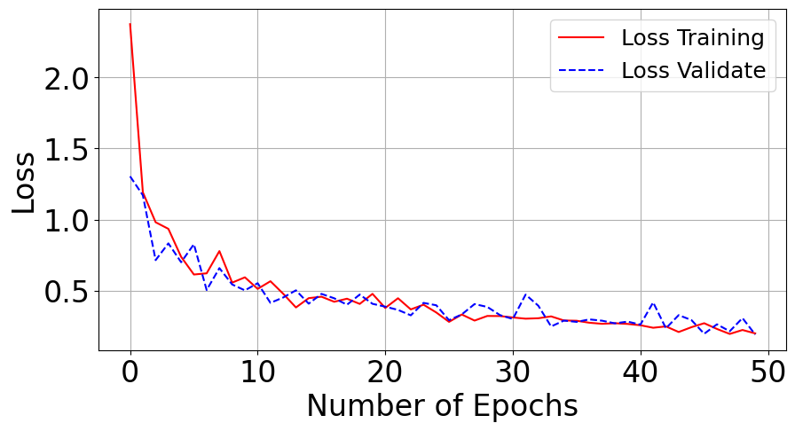

[figure not shown]

```python
plotTraining(model_history,epochs,"loss")
plotTraining(model_history,epochs,"accuracy")
plotTraining(model_history,epochs,"val_loss")
plotTraining(model_history,epochs,"val_accuracy")
```

# Predicción usando el modelo entrenado

```
1/1 ━━━━━━━━━━━━━━━━━━━━ 1s 785ms/step
Clase predicha: EGRETTA THULA
Porcentaje de confianza: 66.31%
```

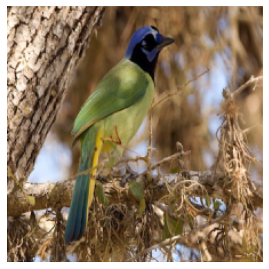

```python
from keras.applications.imagenet_utils import preprocess_input, decode_predictions
from keras.models import load_model

names = ['CYANOCORAX YNCAS', 'PIRANGA RUBRA', 'PITANGUS SULPHURATUS', 'PYROCEPHALUS RUBINUS', 'RUPORNIS MAGNIROSTRIS', 'SICALIS FLAVEOLA', 'THRAUPIS EPISCOPUS', 'TIARIS OLIVACEUS', 'TYRANNUS MELANCHOLICUS', 'ZONOTRICHIA CAPENSIS', 'CATHARTES AURA', 'COEREBA FLAVEOLA', 'COLUMBA LIVIA', 'CORAGYPS ATRATUS', 'CROTOPHAGA SULCIROSTRIS', 'CYANOCORAX YNCAS', 'EGRETTA THULA', 'FALCO PEREGRINUS', 'FALCO SPARVERIUS', 'HIRUNDO RUSTICA', 'PANDION HALIAETUS', 'PILHERODIUS PILEATUS', 'PITANGUS SULPHURATUS', 'PYRRHOMYIAS CINNAMOMEUS', 'RYNCHOPS NIGER', 'SETOPHAGA FUSCA', 'SYNALLAXIS AZARAE', 'TYRANNUS MELANCHOLICUS']

# Cargar el modelo
modelt = load_model(model_directory + file_name)
#modelt = custom_vgg_model

# Ruta de la imagen de prueba
imaget_path = "ImagenPrueba.jpg"

# Leer la imagen, cambiar tamaño y preprocesar
imaget=cv2.resize(cv2.imread(imaget_path), (width_shape, height_shape), interpolation = cv2.INTER_AREA)
xt = np.asarray(imaget)
xt=preprocess_input(xt)
xt = np.expand_dims(xt,axis=0)

# Obtener las predicciones del modelo
preds = modelt.predict(xt)

# Obtener la clase predicha y su porcentaje de confianza
predicted_class_index = np.argmax(preds)
predicted_class_name = names[predicted_class_index]
confidence_percentage = preds[0][predicted_class_index] * 100

# Imprimir el resultado
print(f'Clase predicha: {predicted_class_name}')
print(f'Porcentaje de confianza: {confidence_percentage:.2f}%')

# Mostrar la imagen
plt.imshow(cv2.cvtColor(np.asarray(imaget), cv2.COLOR_BGR2RGB))
plt.axis('off')
plt.show()
```

# Matriz de confusión y métricas de desempeño

```python
from sklearn.metrics import confusion_matrix, f1_score, roc_curve, precision_score, recall_score, accuracy_score, roc_auc_score
from sklearn import metrics
from mlxtend.plotting import plot_confusion_matrix
from keras.models import load_model
import numpy as np
import matplotlib.pyplot as plt
%matplotlib inline


names = ['CATHARTES AURA', 'COEREBA FLAVEOLA', 'COLUMBA LIVIA', 'CORAGYPS ATRATUS', 'CROTOPHAGA SULCIROSTRIS', 'CYANOCORAX YNCAS', 'EGRETTA THULA', 'FALCO PEREGRINUS', 'FALCO SPARVERIUS', 'HIRUNDO RUSTICA', 'PANDION HALIAETUS', 'PILHERODIUS PILEATUS', 'PITANGUS SULPHURATUS', 'PYRRHOMYIAS CINNAMOMEUS', 'RYNCHOPS NIGER', 'SETOPHAGA FUSCA', 'SYNALLAXIS AZARAE', 'TYRANNUS MELANCHOLICUS']



test_data_dir = 'dataset/test'

test_datagen = ImageDataGenerator()

test_generator = test_datagen.flow_from_directory(
    test_data_dir,
    target_size=(width_shape, height_shape),
    batch_size = batch_size,
    class_mode='categorical',
    shuffle=False)

custom_Model= load_model(model_directory + file_name)

predictions = custom_Model.predict(test_generator)


y_pred = np.argmax(predictions, axis=1)
y_real = test_generator.classes


matc=confusion_matrix(y_real, y_pred)



print(metrics.classification_report(y_real,y_pred, digits = 4))
```

```
Found 85 images belonging to 18 classes.
```

```
C:\Users\Oscar Diaz\anaconda3\Lib\site-packages\keras\src\trainers\data_adapters\py_dataset_adapter.py:120: UserWarning: Your `PyDataset` class should call `super().__init__(**kwargs)` in its constructor. `**kwargs` can include `workers`, `use_multiprocessing`, `max_queue_size`. Do not pass these ar…
  self._warn_if_super_not_called()
```

```
3/3 ━━━━━━━━━━━━━━━━━━━━ 9s 3s/step
              precision    recall  f1-score   support

           0     1.0000    0.8000    0.8889         5
           1     0.6667    0.8000    0.7273         5
           2     0.8333    1.0000    0.9091         5
           3     1.0000    0.8000    0.8889         5
           4     0.5556    1.0000    0.7143         5
           5     0.8333    1.0000    0.9091         5
           6     0.5000    1.0000    0.6667         5
           7     0.5556    1.0000    0.7143         5
           8     0.8000    0.8000    0.8000         5
           9     0.3333    0.8000    0.4706         5
          10     1.0000    0.4000    0.5714         5
          11     1.0000    0.6000    0.7500         5
          12     0.0000    0.0000    0.0000         5
          13     0.0000    0.0000    0.0000         5
          14     1.0000    0.6000    0.7500         5
          15     1.0000    0.4000    0.5714         5
          16     0.0000    0.0000    0.0000         5
          17     0.0000    0.0000    0.0000         0

    accuracy                         0.6471        85
   macro avg     0.6154    0.6111    0.5740        85
weighted avg     0.6516    0.6471    0.6078        85
```

[output not shown]

```
C:\Users\Oscar Diaz\anaconda3\Lib\site-packages\mlxtend\plotting\plot_confusion_matrix.py:102: RuntimeWarning: invalid value encountered in divide
  normed_conf_mat = conf_mat.astype("float") / total_samples
```

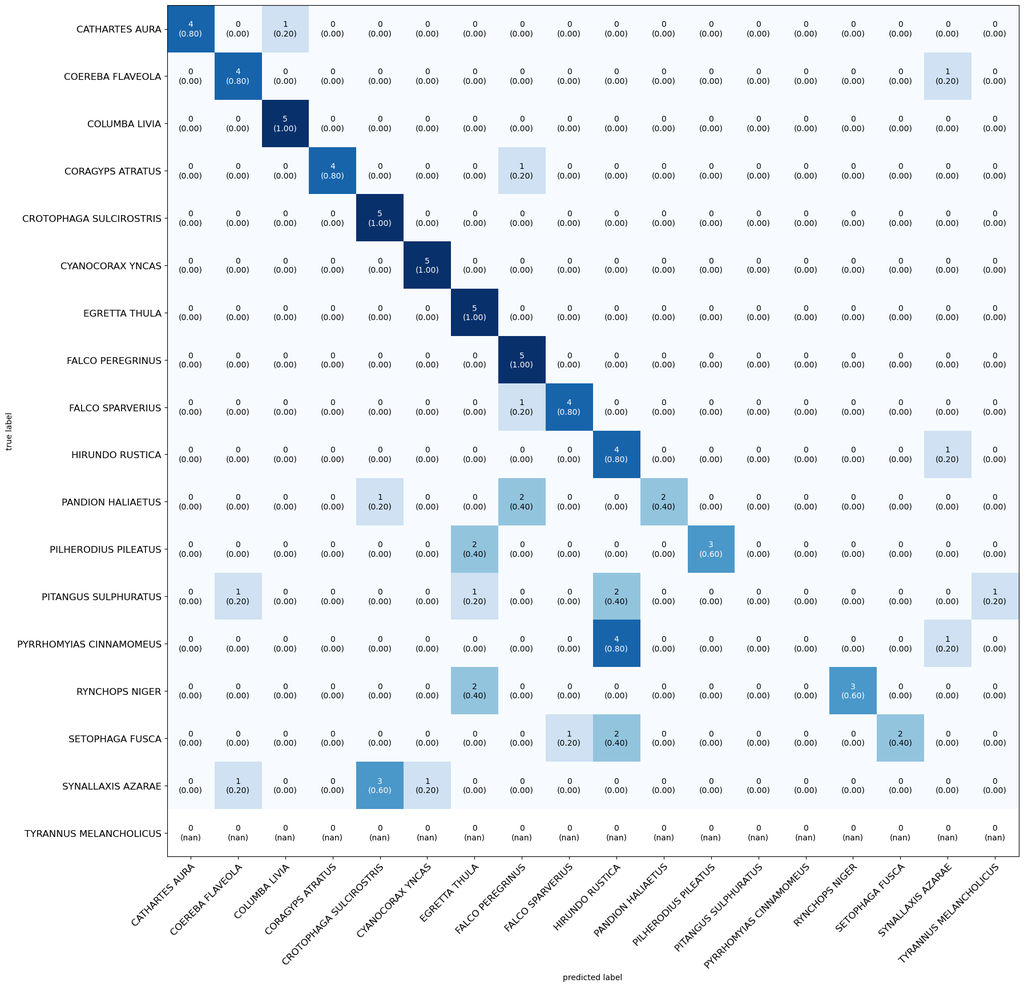

```python
# Define el tamaño de la figura y los nombres de las clases
fig, ax = plot_confusion_matrix(conf_mat=matc, figsize=(18,18), class_names=names, show_normed=True)

# Ajusta el tamaño de las letras de los nombres de las clases
ax.set_xticklabels(names, fontsize=12)  # Ajusta el tamaño de las letras en el eje x
ax.set_yticklabels(names, fontsize=12)  # Ajusta el tamaño de las letras en el eje y

# Ajusta automáticamente el diseño de la figura
plt.tight_layout()

# Muestra la figura
plt.show()
```

# Prueba 2

# Generador de imágenes para las imagenes de train y valid

```python
# Definir el generador de imágenes para el conjunto de entrenamiento con aumentos de datos
train_datagen = ImageDataGenerator(
    rotation_range=20,
    zoom_range=0.2,
    width_shift_range=0.1,
    height_shift_range=0.1,
    horizontal_flip=True,
    vertical_flip=False,
    preprocessing_function=preprocess_input
)

# Definir el generador de imágenes para el conjunto de validación con los mismos aumentos de datos
valid_datagen = ImageDataGenerator(
    rotation_range=20,
    zoom_range=0.2,
    width_shift_range=0.1,
    height_shift_range=0.1,
    horizontal_flip=True,
    vertical_flip=False,
    preprocessing_function=preprocess_input
)

# Definir el número de conjuntos de entrenamiento y validación
num_splits = 3

# Dividir los datos en múltiples conjuntos de entrenamiento y validación
for i in range(num_splits):
    # Crear un generador de lotes de imágenes para el conjunto de entrenamiento
    train_generator = train_datagen.flow_from_directory(
        train_data_dir,
        target_size=(width_shape, height_shape),
        batch_size=batch_size,
        class_mode='categorical'
    )

    # Crear un generador de lotes de imágenes para el conjunto de validación
    validation_generator = valid_datagen.flow_from_directory(
        validation_data_dir,
        target_size=(width_shape, height_shape),
        batch_size=batch_size,
        class_mode='categorical'
    )
```

```
Found 2805 images belonging to 18 classes.
Found 90 images belonging to 18 classes.
Found 2805 images belonging to 18 classes.
Found 90 images belonging to 18 classes.
Found 2805 images belonging to 18 classes.
Found 90 images belonging to 18 classes.
```

# Entrenamiento

```python
from keras.callbacks import LearningRateScheduler
import math

# Definir el número de muestras de entrenamiento y validación
nb_train_samples = 2805
nb_validation_samples = 90

# Definir la entrada de la red neuronal con el tamaño de las imágenes
image_input = Input(shape=(width_shape, height_shape, 3))

# Cargar el modelo VGG16 preentrenado con pesos ajustados desde ImageNet
model = VGG16(input_tensor=image_input, include_top=True, weights='imagenet')

# Obtener la salida de la penúltima capa densa del modelo VGG16 (fc2)
last_layer = model.get_layer('fc2').output

# Añadir una nueva capa densa al final del modelo para la clasificación multiclase con regularización L2 (Evita sobreajuste)
out = Dense(num_classes, activation='softmax', kernel_regularizer='l2', name='output')(last_layer)

# Crear un nuevo modelo personalizado que toma la entrada de la imagen y produce la salida clasificada
custom_vgg_model = Model(image_input, out)

# Congelar todas las capas del modelo, excepto la capa densa añadida
for layer in custom_vgg_model.layers[:-1]:
    layer.trainable = False

# Compilar el modelo con una función de pérdida, optimizador y métricas especificadas
custom_vgg_model.compile(loss='categorical_crossentropy', optimizer=Adam(learning_rate=0.0001), metrics=['accuracy'])

# Definir una función que reduzca la tasa de aprendizaje a la mitad cada 2 épocas
def lr_schedule(epoch):
    initial_lr = 0.0001
    drop = 0.5
    epochs_drop = 2
    lr = initial_lr * math.pow(drop, math.floor((1+epoch)/epochs_drop))
    print("Learning rate set to:", lr)
    return lr



# Crear un callback para ajustar dinámicamente la tasa de aprendizaje
lr_scheduler = LearningRateScheduler(lr_schedule)

# Mostrar un resumen del modelo que incluye la arquitectura y el número de parámetros
custom_vgg_model.summary()

# Entrenar el modelo utilizando generadores de datos para el conjunto de entrenamiento y validación
model_history = custom_vgg_model.fit(
    train_generator,
    epochs=epochs,
    validation_data=validation_generator,
    steps_per_epoch=nb_train_samples//batch_size,  # Número de pasos por época de entrenamiento
    validation_steps=nb_validation_samples//batch_size,  # Número de pasos por época de validación
    callbacks=[lr_scheduler])# Añadir el callback de la tasa de aprendizaje
```

```
Model: "functional_3"
```

```
┏━━━━━━━━━━━━━━━━━━━━━━━━━━━━━━━━━┳━━━━━━━━━━━━━━━━━━━━━━━━┳━━━━━━━━━━━━━━━┓
┃ Layer (type)                    ┃ Output Shape           ┃       Param # ┃
┡━━━━━━━━━━━━━━━━━━━━━━━━━━━━━━━━━╇━━━━━━━━━━━━━━━━━━━━━━━━╇━━━━━━━━━━━━━━━┩
│ input_layer_1 (InputLayer)      │ (None, 224, 224, 3)    │             0 │
├─────────────────────────────────┼────────────────────────┼───────────────┤
│ block1_conv1 (Conv2D)           │ (None, 224, 224, 64)   │         1,792 │
├─────────────────────────────────┼────────────────────────┼───────────────┤
│ block1_conv2 (Conv2D)           │ (None, 224, 224, 64)   │        36,928 │
├─────────────────────────────────┼────────────────────────┼───────────────┤
│ block1_pool (MaxPooling2D)      │ (None, 112, 112, 64)   │             0 │
├─────────────────────────────────┼────────────────────────┼───────────────┤
│ block2_conv1 (Conv2D)           │ (None, 112, 112, 128)  │        73,856 │
├─────────────────────────────────┼────────────────────────┼───────────────┤
│ block2_conv2 (Conv2D)           │ (None, 112, 112, 128)  │       147,584 │
├─────────────────────────────────┼────────────────────────┼───────────────┤
│ block2_pool (MaxPooling2D)      │ (None, 56, 56, 128)    │             0 │
├─────────────────────────────────┼────────────────────────┼───────────────┤
│ block3_conv1 (Conv2D)           │ (None, 56, 56, 256)    │       295,168 │
├─────────────────────────────────┼────────────────────────┼───────────────┤
│ block3_conv2 (Conv2D)           │ (None, 56, 56, 256)    │       590,080 │
├─────────────────────────────────┼────────────────────────┼───────────────┤
│ block3_conv3 (Conv2D)           │ (None, 56, 56, 256)    │       590,080 │
├─────────────────────────────────┼────────────────────────┼───────────────┤
│ block3_pool (MaxPooling2D)      │ (None, 28, 28, 256)    │             0 │
├─────────────────────────────────┼────────────────────────┼───────────────┤
│ block4_conv1 (Conv2D)           │ (None, 28, 28, 512)    │     1,180,160 │
├─────────────────────────────────┼────────────────────────┼───────────────┤
│ block4_conv2 (Conv2D)           │ (None, 28, 28, 512)    │     2,359,808 │
├─────────────────────────────────┼────────────────────────┼───────────────┤
│ block4_conv3 (Conv2D)           │ (None, 28, 28, 512)    │     2,359,808 │
├─────────────────────────────────┼────────────────────────┼───────────────┤
│ block4_pool (MaxPooling2D)      │ (None, 14, 14, 512)    │             0 │
├─────────────────────────────────┼────────────────────────┼───────────────┤
│ block5_conv1 (Conv2D)           │ (None, 14, 14, 512)    │     2,359,808 │
├─────────────────────────────────┼────────────────────────┼───────────────┤
│ block5_conv2 (Conv2D)           │ (None, 14, 14, 512)    │     2,359,808 │
├─────────────────────────────────┼────────────────────────┼───────────────┤
│ block5_conv3 (Conv2D)           │ (None, 14, 14, 512)    │     2,359,808 │
├─────────────────────────────────┼────────────────────────┼───────────────┤
│ block5_pool (MaxPooling2D)      │ (None, 7, 7, 512)      │             0 │
├─────────────────────────────────┼────────────────────────┼───────────────┤
│ flatten (Flatten)               │ (None, 25088)          │             0 │
├─────────────────────────────────┼────────────────────────┼───────────────┤
│ fc1 (Dense)                     │ (None, 4096)           │   102,764,544 │
├─────────────────────────────────┼────────────────────────┼───────────────┤
│ fc2 (Dense)                     │ (None, 4096)           │    16,781,312 │
├─────────────────────────────────┼────────────────────────┼───────────────┤
│ output (Dense)                  │ (None, 18)             │        73,746 │
└─────────────────────────────────┴────────────────────────┴───────────────┘
```

```
 Total params: 134,334,290 (512.44 MB)
```

```
 Trainable params: 73,746 (288.07 KB)
```

```
 Non-trainable params: 134,260,544 (512.16 MB)
```

```
Learning rate set to: 0.0001
```

```
C:\Users\Oscar Diaz\anaconda3\Lib\site-packages\keras\src\trainers\data_adapters\py_dataset_adapter.py:120: UserWarning: Your `PyDataset` class should call `super().__init__(**kwargs)` in its constructor. `**kwargs` can include `workers`, `use_multiprocessing`, `max_queue_size`. Do not pass these ar…
  self._warn_if_super_not_called()
```

```
87/87 ━━━━━━━━━━━━━━━━━━━━ 320s 4s/step - accuracy: 0.2627 - loss: 2.9901 - val_accuracy: 0.8281 - val_loss: 0.9816 - learning_rate: 1.0000e-04
Learning rate set to: 5e-05
 1/87 ━━━━━━━━━━━━━━━━━━━━ 5:18 4s/step - accuracy: 0.6875 - loss: 1.3955
```

```
C:\Users\Oscar Diaz\anaconda3\Lib\contextlib.py:158: UserWarning: Your input ran out of data; interrupting training. Make sure that your dataset or generator can generate at least `steps_per_epoch * epochs` batches. You may need to use the `.repeat()` function when building your dataset.
  self.gen.throw(typ, value, traceback)
```

```
87/87 ━━━━━━━━━━━━━━━━━━━━ 7s 39ms/step - accuracy: 0.6875 - loss: 1.3955 - val_accuracy: 0.6154 - val_loss: 1.3046 - learning_rate: 5.0000e-05
Learning rate set to: 5e-05
87/87 ━━━━━━━━━━━━━━━━━━━━ 314s 4s/step - accuracy: 0.7854 - loss: 1.0984 - val_accuracy: 0.8594 - val_loss: 0.8841 - learning_rate: 5.0000e-05
Learning rate set to: 2.5e-05
87/87 ━━━━━━━━━━━━━━━━━━━━ 6s 30ms/step - accuracy: 0.7188 - loss: 0.9660 - val_accuracy: 0.9231 - val_loss: 0.7396 - learning_rate: 2.5000e-05
Learning rate set to: 2.5e-05
87/87 ━━━━━━━━━━━━━━━━━━━━ 306s 3s/step - accuracy: 0.8557 - loss: 0.8725 - val_accuracy: 0.8438 - val_loss: 0.8213 - learning_rate: 2.5000e-05
Learning rate set to: 1.25e-05
87/87 ━━━━━━━━━━━━━━━━━━━━ 6s 31ms/step - accuracy: 0.9062 - loss: 0.6931 - val_accuracy: 0.8846 - val_loss: 0.7597 - learning_rate: 1.2500e-05
Learning rate set to: 1.25e-05
87/87 ━━━━━━━━━━━━━━━━━━━━ 297s 3s/step - accuracy: 0.8782 - loss: 0.8099 - val_accuracy: 0.9219 - val_loss: 0.6788 - learning_rate: 1.2500e-05
Learning rate set to: 6.25e-06
87/87 ━━━━━━━━━━━━━━━━━━━━ 6s 30ms/step - accuracy: 0.8125 - loss: 0.8384 - val_accuracy: 0.8077 - val_loss: 0.8301 - learning_rate: 6.2500e-06
Learning rate set to: 6.25e-06
87/87 ━━━━━━━━━━━━━━━━━━━━ 297s 3s/step - accuracy: 0.8746 - loss: 0.7692 - val_accuracy: 0.8438 - val_loss: 0.7895 - learning_rate: 6.2500e-06
Learning rate set to: 3.125e-06
87/87 ━━━━━━━━━━━━━━━━━━━━ 6s 30ms/step - accuracy: 0.9375 - loss: 0.5706 - val_accuracy: 0.9231 - val_loss: 0.7769 - learning_rate: 3.1250e-06
Learning rate set to: 3.125e-06
87/87 ━━━━━━━━━━━━━━━━━━━━ 296s 3s/step - accuracy: 0.8766 - loss: 0.7774 - val_accuracy: 0.9062 - val_loss: 0.6919 - learning_rate: 3.1250e-06
Learning rate set to: 1.5625e-06
87/87 ━━━━━━━━━━━━━━━━━━━━ 6s 32ms/step - accuracy: 0.8750 - loss: 0.7578 - val_accuracy: 0.9231 - val_loss: 0.7050 - learning_rate: 1.5625e-06
Learning rate set to: 1.5625e-06
87/87 ━━━━━━━━━━━━━━━━━━━━ 296s 3s/step - accuracy: 0.8920 - loss: 0.7599 - val_accuracy: 0.8594 - val_loss: 0.7321 - learning_rate: 1.5625e-06
Learning rate set to: 7.8125e-07
87/87 ━━━━━━━━━━━━━━━━━━━━ 6s 30ms/step - accuracy: 0.8750 - loss: 0.8360 - val_accuracy: 0.8462 - val_loss: 0.9521 - learning_rate: 7.8125e-07
Learning rate set to: 7.8125e-07
87/87 ━━━━━━━━━━━━━━━━━━━━ 306s 3s/step - accuracy: 0.8925 - loss: 0.7552 - val_accuracy: 0.9375 - val_loss: 0.6446 - learning_rate: 7.8125e-07
Learning rate set to: 3.90625e-07
87/87 ━━━━━━━━━━━━━━━━━━━━ 6s 29ms/step - accuracy: 0.9062 - loss: 0.6771 - val_accuracy: 0.8846 - val_loss: 0.7051 - learning_rate: 3.9062e-07
Learning rate set to: 3.90625e-07
87/87 ━━━━━━━━━━━━━━━━━━━━ 297s 3s/step - accuracy: 0.8914 - loss: 0.7439 - val_accuracy: 0.9062 - val_loss: 0.7160 - learning_rate: 3.9062e-07
Learning rate set to: 1.953125e-07
87/87 ━━━━━━━━━━━━━━━━━━━━ 6s 30ms/step - accuracy: 0.9062 - loss: 0.7391 - val_accuracy: 0.9231 - val_loss: 0.7109 - learning_rate: 1.9531e-07
Learning rate set to: 1.953125e-07
87/87 ━━━━━━━━━━━━━━━━━━━━ 296s 3s/step - accuracy: 0.8956 - loss: 0.7447 - val_accuracy: 0.9375 - val_loss: 0.7051 - learning_rate: 1.9531e-07
Learning rate set to: 9.765625e-08
87/87 ━━━━━━━━━━━━━━━━━━━━ 6s 31ms/step - accuracy: 0.8750 - loss: 0.7531 - val_accuracy: 0.7308 - val_loss: 0.7895 - learning_rate: 9.7656e-08
Learning rate set to: 9.765625e-08
87/87 ━━━━━━━━━━━━━━━━━━━━ 302s 3s/step - accuracy: 0.8937 - loss: 0.7510 - val_accuracy: 0.9375 - val_loss: 0.6711 - learning_rate: 9.7656e-08
Learning rate set to: 4.8828125e-08
```

[output cut: 42 more lines]

```
87/87 ━━━━━━━━━━━━━━━━━━━━ 296s 3s/step - accuracy: 0.8979 - loss: 0.7500 - val_accuracy: 0.9531 - val_loss: 0.6084 - learning_rate: 4.7684e-11
Learning rate set to: 2.384185791015625e-11
87/87 ━━━━━━━━━━━━━━━━━━━━ 6s 31ms/step - accuracy: 0.9062 - loss: 0.7015 - val_accuracy: 0.8077 - val_loss: 0.9279 - learning_rate: 2.3842e-11
Learning rate set to: 2.384185791015625e-11
87/87 ━━━━━━━━━━━━━━━━━━━━ 296s 3s/step - accuracy: 0.9023 - loss: 0.7475 - val_accuracy: 0.9062 - val_loss: 0.7125 - learning_rate: 2.3842e-11
Learning rate set to: 1.1920928955078126e-11
87/87 ━━━━━━━━━━━━━━━━━━━━ 6s 31ms/step - accuracy: 0.8125 - loss: 0.9087 - val_accuracy: 0.8846 - val_loss: 0.8064 - learning_rate: 1.1921e-11
Learning rate set to: 1.1920928955078126e-11
87/87 ━━━━━━━━━━━━━━━━━━━━ 295s 3s/step - accuracy: 0.8690 - loss: 0.8052 - val_accuracy: 0.8750 - val_loss: 0.7635 - learning_rate: 1.1921e-11
Learning rate set to: 5.960464477539063e-12
87/87 ━━━━━━━━━━━━━━━━━━━━ 6s 30ms/step - accuracy: 0.9688 - loss: 0.7053 - val_accuracy: 0.9615 - val_loss: 0.5546 - learning_rate: 5.9605e-12
Learning rate set to: 5.960464477539063e-12
87/87 ━━━━━━━━━━━━━━━━━━━━ 302s 3s/step - accuracy: 0.8988 - loss: 0.7302 - val_accuracy: 0.9531 - val_loss: 0.6477 - learning_rate: 5.9605e-12
Learning rate set to: 2.9802322387695314e-12
87/87 ━━━━━━━━━━━━━━━━━━━━ 6s 30ms/step - accuracy: 0.9062 - loss: 0.9430 - val_accuracy: 0.9615 - val_loss: 0.6262 - learning_rate: 2.9802e-12
```

# Grabar modelo en disco

Guardar el modelo tiene varias ventajas. En primer lugar, permite la reutilización futura, ya que puedes cargarlo y utilizarlo nuevamente sin necesidad de volver a entrenarlo desde cero, lo que resulta útil tanto para hacer predicciones en nuevos datos como para continuar el entrenamiento en una fecha posterior. Además, facilita la distribución y compartición del modelo con otros investigadores, colegas o clientes que puedan necesitar utilizarlo en sus propios proyectos. Por último, al guardar el modelo junto con su configuración y pesos entrenados, se asegura la reproducibilidad de los resultados, ya que otros investigadores pueden cargar el modelo exacto y obtener los mismos resultados que tú, lo que es fundamental para la validación y la comparación de resultados en investigación científica y desarrollo de modelos.

Este código utilizará un bucle while para verificar si el archivo con el nombre base del modelo ya existe. Si existe, agregará un número al final del nombre del archivo y verificará nuevamente. Esto continuará hasta que se encuentre un nombre de archivo único que no exista en el directorio. Una vez que se encuentra un nombre único, el modelo se guarda con ese nombre.

```python
import os

# Nombre base del modelo
model_name = "model_VGG16_v"

# Extensión del archivo
file_extension = ".keras"

# Directorio donde se guardarán los modelos
model_directory = "models/"

# Inicializar contador
counter = 1

# Generar el nombre completo del archivo
file_name = model_name + file_extension

ruta=model_directory + file_name
print(ruta)
# Verificar si el modelo ya está guardado
while os.path.exists(model_directory + file_name):

    # Si el archivo existe, agregar un número al final del nombre del modelo
    file_name = f"{model_name}{counter}{file_extension}"
    counter += 1

# Guardar el modelo con el nombre único en el directorio correcto
custom_vgg_model.save(model_directory + file_name)
```

```
models/model_VGG16_v.keras
```

# Gráficas de entrenamiento y validación (accuracy - loss)

```python
def plotTraining(hist, epochs, typeData):

    if typeData=="loss":
        plt.figure(1,figsize=(10,5))
        yc=hist.history['loss']
        xc=range(epochs)
        plt.ylabel('Loss', fontsize=24)
        plt.plot(xc,yc,'-r',label='Loss Training')
    if typeData=="accuracy":
        plt.figure(2,figsize=(10,5))
        yc=hist.history['accuracy']
        for i in range(0, len(yc)):
            yc[i]=100*yc[i]
        xc=range(epochs)
        plt.ylabel('Accuracy (%)', fontsize=24)
        plt.plot(xc,yc,'-r',label='Accuracy Training')
    if typeData=="val_loss":
        plt.figure(1,figsize=(10,5))
        yc=hist.history['val_loss']
        xc=range(epochs)
        plt.ylabel('Loss', fontsize=24)
        plt.plot(xc,yc,'--b',label='Loss Validate')
    if typeData=="val_accuracy":
        plt.figure(2,figsize=(10,5))
        yc=hist.history['val_accuracy']
        for i in range(0, len(yc)):
            yc[i]=100*yc[i]
        xc=range(epochs)
        plt.ylabel('Accuracy (%)', fontsize=24)
        plt.plot(xc,yc,'--b',label='Training Validate')


    plt.rc('xtick',labelsize=24)
    plt.rc('ytick',labelsize=24)
    plt.rc('legend', fontsize=18)
    plt.legend()
    plt.xlabel('Number of Epochs',fontsize=24)
    plt.grid(True)
```

[figure not shown]

[figure not shown]

```python
plotTraining(model_history,epochs,"loss")
plotTraining(model_history,epochs,"accuracy")
plotTraining(model_history,epochs,"val_loss")
plotTraining(model_history,epochs,"val_accuracy")
```

# Predicción usando el modelo entrenado

```
1/1 ━━━━━━━━━━━━━━━━━━━━ 1s 656ms/step
Clase predicha: CYANOCORAX YNCAS
Porcentaje de confianza: 89.46%
```

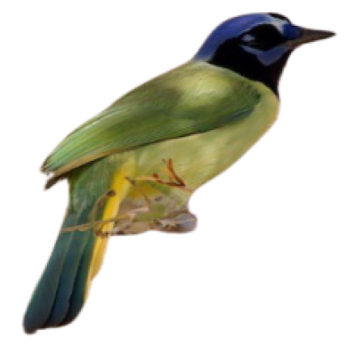

```python
from keras.applications.imagenet_utils import preprocess_input, decode_predictions
from keras.models import load_model

names = ['CATHARTES AURA', 'COEREBA FLAVEOLA', 'COLUMBA LIVIA', 'CORAGYPS ATRATUS', 'CROTOPHAGA SULCIROSTRIS', 'CYANOCORAX YNCAS', 'EGRETTA THULA', 'FALCO PEREGRINUS', 'FALCO SPARVERIUS', 'HIRUNDO RUSTICA', 'PANDION HALIAETUS', 'PILHERODIUS PILEATUS', 'PITANGUS SULPHURATUS', 'PYRRHOMYIAS CINNAMOMEUS', 'RYNCHOPS NIGER', 'SETOPHAGA FUSCA', 'SYNALLAXIS AZARAE', 'TYRANNUS MELANCHOLICUS']

# Cargar el modelo
modelt = load_model(model_directory + file_name)
#modelt = custom_vgg_model

# Ruta de la imagen de prueba
imaget_path = "ImagenPrueba_SF.png"

# Leer la imagen, cambiar tamaño y preprocesar
imaget=cv2.resize(cv2.imread(imaget_path), (width_shape, height_shape), interpolation = cv2.INTER_AREA)
xt = np.asarray(imaget)
xt=preprocess_input(xt)
xt = np.expand_dims(xt,axis=0)

# Obtener las predicciones del modelo
preds = modelt.predict(xt)

# Obtener la clase predicha y su porcentaje de confianza
predicted_class_index = np.argmax(preds)
predicted_class_name = names[predicted_class_index]
confidence_percentage = preds[0][predicted_class_index] * 100

# Imprimir el resultado
print(f'Clase predicha: {predicted_class_name}')
print(f'Porcentaje de confianza: {confidence_percentage:.2f}%')

# Mostrar la imagen
plt.imshow(cv2.cvtColor(np.asarray(imaget), cv2.COLOR_BGR2RGB))
plt.axis('off')
plt.show()
```

# Matriz de confusión y métricas de desempeño

```
Found 86 images belonging to 18 classes.
3/3 ━━━━━━━━━━━━━━━━━━━━ 9s 3s/step
```

[output not shown]

```
              precision    recall  f1-score   support

           0     1.0000    0.2000    0.3333         5
           1     0.5714    0.8000    0.6667         5
           2     0.8333    1.0000    0.9091         5
           3     1.0000    1.0000    1.0000         5
           4     0.6250    1.0000    0.7692         5
           5     0.7500    1.0000    0.8571         6
           6     0.4444    0.8000    0.5714         5
           7     0.4167    1.0000    0.5882         5
           8     1.0000    0.8000    0.8889         5
           9     0.1250    0.2000    0.1538         5
          10     0.5000    0.2000    0.2857         5
          11     0.2500    0.2000    0.2222         5
          12     0.0000    0.0000    0.0000         5
          13     1.0000    0.4000    0.5714         5
          14     1.0000    0.6000    0.7500         5
          15     1.0000    0.2000    0.3333         5
          16     0.0000    0.0000    0.0000         5
          17     0.0000    0.0000    0.0000         0

    accuracy                         0.5581        86
   macro avg     0.5842    0.5222    0.4945        86
weighted avg     0.6201    0.5581    0.5274        86
```

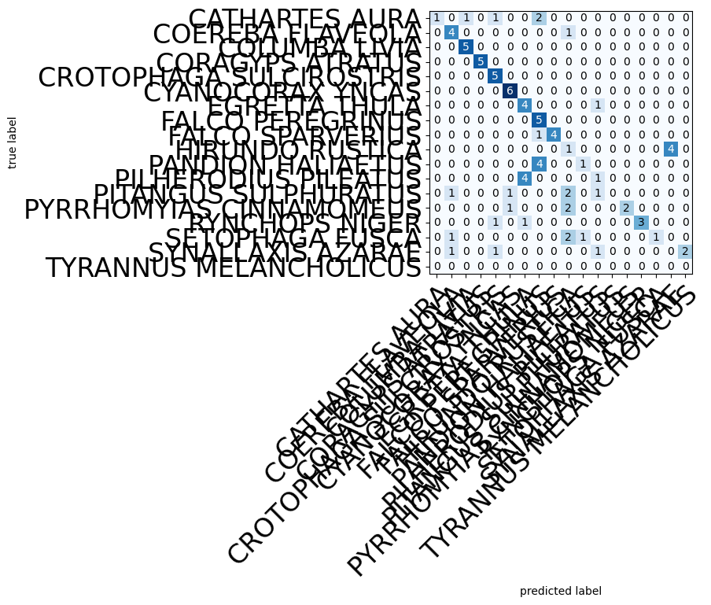

```python
from sklearn.metrics import confusion_matrix, f1_score, roc_curve, precision_score, recall_score, accuracy_score, roc_auc_score
from sklearn import metrics
from mlxtend.plotting import plot_confusion_matrix
from keras.models import load_model
import numpy as np
import matplotlib.pyplot as plt
%matplotlib inline


names = ['CATHARTES AURA', 'COEREBA FLAVEOLA', 'COLUMBA LIVIA', 'CORAGYPS ATRATUS', 'CROTOPHAGA SULCIROSTRIS', 'CYANOCORAX YNCAS', 'EGRETTA THULA', 'FALCO PEREGRINUS', 'FALCO SPARVERIUS', 'HIRUNDO RUSTICA', 'PANDION HALIAETUS', 'PILHERODIUS PILEATUS', 'PITANGUS SULPHURATUS', 'PYRRHOMYIAS CINNAMOMEUS', 'RYNCHOPS NIGER', 'SETOPHAGA FUSCA', 'SYNALLAXIS AZARAE', 'TYRANNUS MELANCHOLICUS']



test_data_dir = 'dataset/test'

test_datagen = ImageDataGenerator()

test_generator = test_datagen.flow_from_directory(
    test_data_dir,
    target_size=(width_shape, height_shape),
    batch_size = batch_size,
    class_mode='categorical',
    shuffle=False)

custom_Model= load_model(model_directory + file_name)

predictions = custom_Model.predict(test_generator)


y_pred = np.argmax(predictions, axis=1)
y_real = test_generator.classes


matc=confusion_matrix(y_real, y_pred)

plot_confusion_matrix(conf_mat=matc, figsize=(9,9), class_names = names, show_normed=False)
plt.tight_layout()

print(metrics.classification_report(y_real,y_pred, digits = 4))
```

```
C:\Users\Oscar Diaz\anaconda3\Lib\site-packages\mlxtend\plotting\plot_confusion_matrix.py:102: RuntimeWarning: invalid value encountered in divide
  normed_conf_mat = conf_mat.astype("float") / total_samples
```

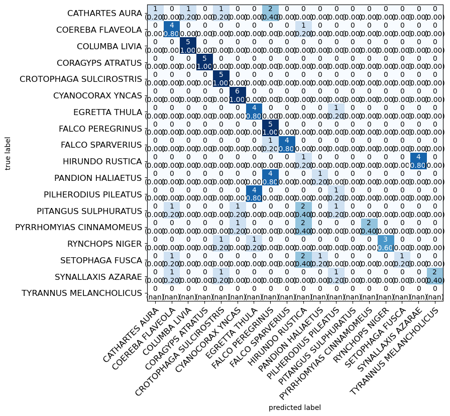

```python
# Define el tamaño de la figura y los nombres de las clases
fig, ax = plot_confusion_matrix(conf_mat=matc, figsize=(9,9), class_names=names, show_normed=True)

# Ajusta el tamaño de las letras de los nombres de las clases
ax.set_xticklabels(names, fontsize=12)  # Ajusta el tamaño de las letras en el eje x
ax.set_yticklabels(names, fontsize=12)  # Ajusta el tamaño de las letras en el eje y

# Ajusta automáticamente el diseño de la figura
plt.tight_layout()

# Muestra la figura
plt.show()
```